# Лекция 1. Почему «регрессия с контролями» — не ответ

Блок 0. Данные и язык причинности

Карен Аванесян

Каузальный анализ в R на данных RLMS-HSE

# Зачем

## Все интересные вопросы — «что будет, если…»

- Повысит ли **высшее образование** зарплату тех, кто его получит?
- **Снизит** ли курение заработок? Или просто курильщики — другие люди?
- Выйдут ли женщины на работу раньше, если **ясли** станут доступнее?
- Что сделает **повышение пенсионного возраста** с занятостью 55-летних?

Каждый из этих вопросов сравнивает **два мира**: тот, где воздействие есть, и тот, где его нет. В данных мы видим только один из них.

## Прогноз и причина — разные задачи

прогноз

### По признакам угадать исход

- «Кто из респондентов, вероятно, курит?»
- «Какая зарплата у человека с таким профилем?»
- Критерий: точность на новых данных
- Корреляции — это нормально

причинный вывод

### Что изменится, если *вмешаться*

- «Как изменится зарплата, если *этот* человек бросит курить?»
- Критерий: правильные **контрфактические** предсказания
- Корреляции — чаще всего ловушка

Отличная предсказательная модель может быть бесполезна для политики: число пожарных прекрасно предсказывает ущерб от пожара.

## План занятия

1. Потенциальные исходы и фундаментальная проблема
2. Эстиманды: ATE, ATT и компания
3. Наивная разница = эффект + смещение отбора
4. Парадокс Симпсона на RLMS
5. Симуляция: когда контроли спасают, а когда нет

# Идея

## Два потенциальных исхода

Для каждого человека $i$ и бинарного воздействия $D_i \in \{0, 1\}$ (например, диплом):

- $Y_i(1)$ — зарплата, **если бы** у него был диплом
- $Y_i(0)$ — зарплата, **если бы** диплома не было
- Индивидуальный эффект: $\tau_i = Y_i(1) - Y_i(0)$

Наблюдаем только одно:

$$Y_i = D_i \, Y_i(1) + (1 - D_i) \, Y_i(0)$$

**Фундаментальная проблема причинного вывода** (Holland, 1986): второй исход для того же человека не наблюдается никогда. Причинный вывод — это задача о **пропущенных данных**.

## Таблица, которую мы никогда не увидим целиком

| Человек | Диплом (D) | Y(1) | Y(0) | τ = Y(1) − Y(0) | Наблюдаем Y |
| --- | --- | --- | --- | --- | --- |
| Анна | 1 | 52 | 45 | 7 | 52 |
| Борис | 0 | 38 | 33 | 5 | 33 |
| Вера | 1 | 60 | 48 | 12 | 60 |
| Глеб | 0 | 41 | 40 | 1 | 40 |
| Дарья | 1 | 45 | 41 | 4 | 45 |
| Егор | 0 | 35 | 30 | 5 | 30 |

- Средний эффект по всем шести: **ATE = 5.667** тыс. руб.
- Наивное сравнение по наблюдаемому $Y$: 18 тыс. — потому что Анна, Вера и Дарья зарабатывали бы больше **и без диплома**

## Эстиманды: сначала вопрос, потом метод

| Эстиманд | Формула | Вопрос |
| --- | --- | --- |
| **ATE** | $E[Y(1) - Y(0)]$ | эффект для случайного человека из популяции |
| **ATT** | $E[Y(1) - Y(0) \mid D = 1]$ | эффект для тех, кто воздействие **получил** |
| **ATU** | $E[Y(1) - Y(0) \mid D = 0]$ | что получили бы те, кто **не** получил |
| **CATE** | $E[Y(1) - Y(0) \mid X = x]$ | эффект для группы с признаками $x$ |
| **LATE** | эффект для «комплаеров» | тех, кого инструмент сдвинул (лекция 12) |

Привычка курса: любая оценка начинается с фразы «**мой эстиманд — …, популяция — …, воздействие — …, исход — …**». Разные методы отвечают на разные вопросы, и это не недостаток, а свойство.

## Разложение наивной разницы

Сравнили средние зарплаты с дипломом и без:

$$\begin{aligned}
\underbrace{E[Y \mid D=1] - E[Y \mid D=0]}_{\text{наивная разница}}
&= \underbrace{E[Y(1) - Y(0) \mid D=1]}_{\text{ATT}} \\
&\quad + \underbrace{E[Y(0) \mid D=1] - E[Y(0) \mid D=0]}_{\text{смещение отбора}}
\end{aligned}$$

- **Смещение отбора**: насколько получившие диплом отличались бы от остальных *и без диплома* — способности, семья, город, мотивация
- Если эффект разный у людей, добавляется ещё член: разница между ATT и ATU, взвешенная долей необработанных
- Рандомизация делает смещение **нулевым** в среднем — об этом лекция 2

## Когда наивная разница — это эффект

допущение 1

### Независимость

$\{Y(0), Y(1)\} \perp D$ — кто получил воздействие, не связано с тем, какими были бы исходы.

Выполняется в эксперименте с рандомизацией; в наблюдательных данных — почти никогда «просто так».

допущение 2

### Условная независимость

$\{Y(0), Y(1)\} \perp D \mid X$ — внутри групп с одинаковыми $X$ воздействие «как случайное».

Это и есть обещание «регрессии с контролями». Проблема: нужно, чтобы $X$ включал **всё**, от чего зависит и отбор, и исход. Способности в RLMS не измерены.

допущение 3

### Общая поддержка

При каждом $x$ есть и обработанные, и необработанные.

## Три источника смещения

конфаундер — общая причина

### Способности → диплом и → зарплата

**Что делать:** измерить и условиться; найти квазиэксперимент

обратная причинность

### Плохое здоровье → безработица

…а не только наоборот. **Что делать:** панель, порядок во времени, инструменты

отбор в выборку / коллайдер

### Смотрим зарплаты только занятых

**Что делать:** понять, кто выпал; DAG (лекция 3)

«Добавим контролей» лечит только первое, и то лишь если мы контролируем *правильные* переменные. Контроль за *неправильными* делает хуже.

## SUTVA: о чём молчат формулы

Чтобы $Y_i(1)$ вообще имел смысл, нужны два допущения:

1. **Нет взаимовлияния**: исход Анны не зависит от того, получил ли диплом Борис (на тесных рынках труда — спорно)
2. **Одна версия воздействия**: «высшее образование» — одно и то же для всех (МГУ и заочный филиал — не одно и то же)

Практический вывод: формулируйте воздействие так, чтобы его можно было **представить как вмешательство** — «получить диплом бакалавра к 25 годам», а не «быть образованным».

# Код

## Наивная разница на RLMS

```r
work <- adults |> filter(employed == 1, !is.na(log_wage), !is.na(higher_ed), age >= 25)

work |> group_by(higher_ed) |>
  summarise(n = n(), mean_log_wage = mean(log_wage), wage_2024 = median(wage_real)) |>
  mutate(diff = mean_log_wage - mean_log_wage[higher_ed == 0])
```

| higher_ed | n | mean_log_wage | wage_2024 | diff |
| --- | --- | --- | --- | --- |
| 0 | 104809 | 10.2 | 29434 | 0.000 |
| 1 | 50773 | 10.6 | 42130 | 0.376 |

Разница ≈ 0.38 лога — зарплата выше примерно на 45 %. Что из этого **эффект диплома**, а что — то, что в вуз чаще идут дети образованных родителей из больших городов?

## Симуляция: мир, где мы знаем правду

Создадим 5 000 человек, у которых мы **видим оба потенциальных исхода**. Истинный эффект диплома — ровно 0.2:

```r
set.seed(2026)
n <- 5000
sim <- tibble(
  ability = rnorm(n),
  y0 = 10 + 0.5 * ability + rnorm(n, 0, 0.5),        # зарплата без диплома
  y1 = y0 + 0.2,                                     # эффект одинаков для всех
  d  = as.integer(ability + rnorm(n) > 0.5)          # способные чаще идут в вуз
) |> mutate(y = ifelse(d == 1, y1, y0))              # наблюдаем только одно

sim |> summarise(
  ATE   = mean(y1 - y0),
  naive = mean(y[d == 1]) - mean(y[d == 0]),
  bias  = mean(y0[d == 1]) - mean(y0[d == 0])        # смещение отбора
)
```

| ATE | naive | bias |
| --- | --- | --- |
| 0.2 | 0.764 | 0.564 |

## Та же симуляция с рандомизацией

```r
sim_rct <- sim |> mutate(d = rbinom(n, 1, 0.4), y = ifelse(d == 1, y1, y0))

sim_rct |> summarise(
  ATE   = mean(y1 - y0),
  naive = mean(y[d == 1]) - mean(y[d == 0]),
  bias  = mean(y0[d == 1]) - mean(y0[d == 0])
)
```

| ATE | naive | bias |
| --- | --- | --- |
| 0.2 | 0.21 | 0.01 |

Один и тот же мир, те же люди, тот же эффект. Единственное, что изменилось — **правило назначения** $D$. Именно его мы изучаем весь курс.

## Что бывает при повторении

- Результат
- Код

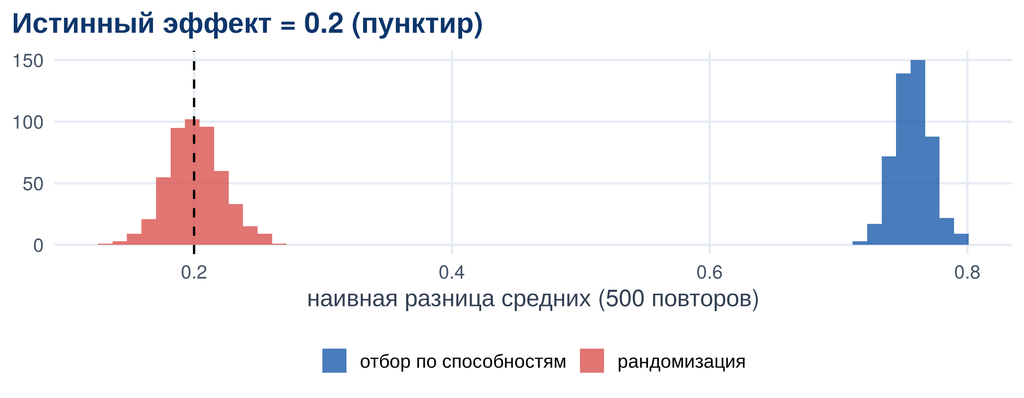

```r
one_draw <- function(randomize = FALSE) {
  d <- if (randomize) rbinom(n, 1, 0.4) else as.integer(sim$ability + rnorm(n) > 0.5)
  y <- ifelse(d == 1, sim$y1, sim$y0)
  mean(y[d == 1]) - mean(y[d == 0])
}
draws <- tibble(
  `отбор по способностям` = replicate(500, one_draw(FALSE)),
  `рандомизация`          = replicate(500, one_draw(TRUE))
) |> pivot_longer(everything(), names_to = "дизайн", values_to = "оценка")

ggplot(draws, aes(оценка, fill = дизайн)) +
  geom_histogram(bins = 60, alpha = 0.8, position = "identity") +
  geom_vline(xintercept = 0.2, linetype = 2) +
  labs(x = "наивная разница средних (500 повторов)", y = NULL, fill = NULL,
       title = "Истинный эффект = 0.2 (пунктир)")
```

## Контроль спасает — если контроль правильный

В симуляции единственный конфаундер — `ability`, и мы его **видим**. Тогда регрессия с контролем даёт правду:

```r
etable(
  feols(y ~ d, data = sim),
  feols(y ~ d + ability, data = sim),
  headers = c("наивная", "+ способности")
)
```

|  | feols(y ~ d, d.. | feols(y ~ d + .. |
| --- | --- | --- |
|  | наивная | + способности |
| Dependent Var.: | y | y |
| Constant | 9.80*** (0.011) | 10.0*** (0.010) |
| d | 0.764*** (0.019) | 0.202*** (0.018) |
| ability |  | 0.491*** (0.009) |
| _______________ | ________________ | ________________ |
| S.E. type | IID | IID |
| Observations | 5,000 | 5,000 |
| R2 | 0.24 | 0.54 |

## …а в RLMS способностей нет

```r
m1 <- feols(log_wage ~ higher_ed, data = work, cluster = ~psu)
m2 <- feols(log_wage ~ higher_ed + female + age + I(age^2), data = work, cluster = ~psu)
m3 <- feols(log_wage ~ higher_ed + female + age + I(age^2) + settlement | year,
            data = work, cluster = ~psu)
etable(m1, m2, m3, keep = "higher_ed",
       headers = c("наивная", "+ пол, возраст", "+ поселение, год"))
```

|  | m1 | m2 | m3 |
| --- | --- | --- | --- |
|  | наивная | + пол, возраст | + поселение, год |
| Dependent Var.: | log_wage | log_wage | log_wage |
| higher_ed | 0.376*** (0.032) | 0.430*** (0.032) | 0.316*** (0.017) |
| _______________ | ________________ | ________________ | ________________ |
| S.E.: Clustered | by: psu | by: psu | by: psu |
| Observations | 155,582 | 155,582 | 155,582 |
| R2 | 0.05 | 0.13 | 0.31 |

## Как читать вывод `summary()`: регрессия на дамми

- Вывод R
- С пояснениями

```
OLS estimation, Dep. Var.: log_wage
Observations: 155,582
Standard-errors: Clustered (psu)
            Estimate Std. Error t value             Pr(>|t|)
(Intercept)   10.228     0.0572   178.9            < 2.2e-16 ***
higher_ed      0.376     0.0323    11.6 0.000000000000061117 ***
---
Signif. codes:  0 '***' 0.001 '**' 0.01 '*' 0.05 '.' 0.1 ' ' 1
RMSE: 0.779797   Adj. R2: 0.048562
```

1 · шапка

**OLS**, зависимая `log_wage`, **Observations** — 155 582: ровно столько строк в `work`, пропусков нет. Тип ошибок — **Clustered (psu)**

2 · (Intercept)

Средний лог зарплаты **без** диплома: 10.228 — то же число, что `mean_log_wage` при `higher_ed = 0` в таблице с `group_by()`

3 · higher_ed

Регрессия на дамми = **разница средних**: 0.376 = столбец `diff`. В процентах: $e^b - 1$ ≈ 46 %

4 · SE, t, p

t = оценка / ошибка. p-value напечатан длинной строкой нулей (в курсе `scipen = 999`): это просто «почти ноль»

5 · Adj. R2

Диплом объясняет 5 % разброса зарплат. Для причинного вопроса R² не важен: низкий R² не делает оценку смещённой, высокий — не делает её эффектом

6 · сигналы беды

Читать `higher_ed` как эффект: это ATT **плюс смещение отбора**. Сигнал — оценка заметно меняется при добавлении контролей (следующий слайд)

## Что говорит и о чём молчит эта таблица

0.38 наивная оценка

0.43 + пол и возраст

0.32 + тип поселения и год

Контроли двигают оценку в обе стороны.

- Контроль за полом **повышает** оценку: женщины чаще имеют диплом и меньше зарабатывают — без контроля они «прячут» часть отдачи
- Контроль за поселением **понижает**: дипломы концентрируются в больших городах, где выше все зарплаты
- Каждый новый контроль меняет оценку — значит, отбор есть
- Сколько ещё объяснили бы способности, семья, мотивация, из этой таблицы **не узнать**: их в данных нет
- Направление смещения можно обсуждать (лекция 17, анализ чувствительности), но «добавить контролей» — не доказательство

## Как писать результат

шаблон

«Среди работающих респондентов RLMS-HSE в возрасте 25 лет и старше (155 582 наблюдений, 2000–2025) зарплата людей с высшим образованием в среднем на **37 %** выше, чем у людей без него, при одинаковых поле, возрасте, типе поселения и годе (разница логарифмов 0.316, s.e. 0.017, ошибки кластеризованы по 38 площадкам). Это условная разница средних, а не эффект диплома: способности и семейный фон в модели не учтены.»

- Обязательно: выборка и N, что именно учтено, тип ошибок, перевод лог-пунктов в проценты ($e^b - 1$)
- Не писать «высшее образование повышает зарплату на …» и «отдача от образования составляет …» — это язык эффекта, а дизайна для эффекта здесь нет

## Гетерогенные эффекты: ATT ≠ ATE

Пусть диплом даёт больше тем, у кого выше способности:

```r
sim_h <- sim |>
  mutate(y1 = y0 + 0.2 + 0.3 * ability, y = ifelse(d == 1, y1, y0))

sim_h |> summarise(
  ATE = mean(y1 - y0),
  ATT = mean((y1 - y0)[d == 1]),
  ATU = mean((y1 - y0)[d == 0]),
  naive = mean(y[d == 1]) - mean(y[d == 0])
)
```

| ATE | ATT | ATU | naive |
| --- | --- | --- | --- |
| 0.198 | 0.417 | 0.074 | 0.982 |

- ATT > ATE: диплом получили те, кому он даёт больше — это **рациональный отбор**, а не ошибка
- Политика «всем в вуз» даст ATU, а не ATT. Какой эстиманд вам нужен?

## Парадокс Симпсона: курение и занятость

```r
smk <- adults |> filter(age >= 25, age <= 60, !is.na(smokes))

by_group <- function(d, g) d |>
  group_by(группа = g, smokes) |>
  summarise(занятость = mean(employed), n = n(), .groups = "drop")

bind_rows(by_group(smk, "все"), by_group(smk, as.character(smk$sex))) |>
  pivot_wider(names_from = smokes, values_from = c(занятость, n)) |>
  mutate(разница = занятость_1 - занятость_0)
```

| группа | занятость_0 | занятость_1 | n_0 | n_1 | разница |
| --- | --- | --- | --- | --- | --- |
| все | 0.765 | 0.767 | 135999 | 79478 | 0.002 |
| Женщины | 0.740 | 0.728 | 95994 | 22826 | -0.012 |
| Мужчины | 0.826 | 0.782 | 40005 | 56652 | -0.044 |

В целом курильщики заняты **так же**, как некурящие. Но среди мужчин — реже, и среди женщин — реже. Пол — конфаундер: мужчины и курят чаще, и работают чаще.

## Парадокс Симпсона: алкоголь и зарплата

| группа | пьёт_0 | пьёт_1 | разница |
| --- | --- | --- | --- |
| все | 10.3 | 10.4 | 0.080 |
| Женщины | 10.2 | 10.2 | 0.066 |
| Мужчины | 10.6 | 10.5 | -0.091 |

- В целом те, кто пьёт еженедельно, зарабатывают **больше**
- Среди мужчин — **меньше**, среди женщин — лишь немного больше: общая разница отражает в основном то, что мужчины и пьют чаще, и зарабатывают больше
- Какая цифра «правильная»? Та, что отвечает на корректно заданный вопрос с правильным набором условий. Решает не статистика, а **структура причин** — DAG, лекция 3

## Обратная причинность: здоровье и работа

Безработные хуже оценивают здоровье. Это безработица вредит здоровью — или здоровье мешает работать? Панель позволяет посмотреть **порядок во времени**:

```r
next_year <- adults |>                                  # занятость через год
  transmute(idind, year = year - 1, employed_next = employed)

hw <- adults |>
  filter(age >= 25, age <= 55, employed == 1, !is.na(poor_health)) |>
  select(idind, year, poor_health) |>
  inner_join(next_year, by = c("idind", "year"))

hw |> group_by(`плохое здоровье в t` = poor_health) |>
  summarise(`доля занятых в t+1` = mean(employed_next), n = n())
```

| плохое здоровье в t | доля занятых в t+1 | n |
| --- | --- | --- |
| 0 | 0.940 | 122056 |
| 1 | 0.885 | 4532 |

Среди *занятых* те, кто оценивает здоровье как плохое, через год чаще теряют работу. Направление здоровье → занятость существует; значит, наивное сравнение здоровья безработных и занятых смешивает оба направления.

# Как ошибаются

## Пять типичных ошибок

1. **Прогноз выдают за эффект**: «модель показывает, что курение связано со снижением зарплаты на 8 %» — связь, а не снижение
2. **Эстиманд не назван**: ATE или ATT? Для кого? Оценки разных методов сравнивают как будто они об одном
3. **Контроли вместо дизайна**: добавили 20 переменных и объявили оценку причинной
4. **Интерпретируют все коэффициенты**: в регрессии зарплаты на диплом коэффициент при «женщина» — **не** эффект пола (Table 2 fallacy)
5. **Не думают о правиле назначения**: кто и почему получает воздействие — главный вопрос, который нужно задать *до* оценки

## Вопросы, которые нужно задать до регрессии

- Что именно является воздействием и можно ли его **вмешательством** изменить?
- Кто **выбирает** воздействие — человек, работодатель, государство, случай?
- Что из того, что влияет на выбор, влияет **и на исход**? Что из этого измерено?
- Для **кого** нужен эффект: для всех, для получивших, для тех, кого затронет политика?
- Исход измерен **после** воздействия?

# Мини-задача

## Задание к следующему занятию

1. Сформулируйте **три** причинных вопроса к данным RLMS. Для каждого запишите: воздействие, исход, популяцию, эстиманд и главную «историю отбора» (кто и почему получает воздействие)
2. Для одного из них посчитайте наивную разницу средних и разницу внутри подгрупп по полу и типу поселения. Меняется ли знак?
3. Измените симуляцию так, чтобы наивная разница оказалась **меньше** истинного эффекта (подсказка: отрицательный отбор). Приведите реалистичный пример такой ситуации

# Литература

## Что прочитать

- Holland P. (1986). Statistics and Causal Inference. *JASA*, 81(396), 945–960 — откуда взялась «фундаментальная проблема»
- Cunningham S. *The Mixtape*, гл. 4 «Potential Outcomes Causal Model» — разложение наивной разницы
- Huntington-Klein N. *The Effect*, гл. 5–6 — identification, treatment effects
- Hernán M., Robins J. *What If*, гл. 1–3 — определение эффекта, рандомизация, наблюдательные данные
- Angrist J., Pischke J.-S. *Mastering ’Metrics*, гл. 1 — «селекция»

Каузальный анализ в R · RLMS-HSE · К. Аванесян

← К программе курса